# Gastric cancer: exploratory analysis

CCDL for ALSF

2021

## Objectives

This notebook will demonstrate how to:

- Create a `DESeq2` data set from a `SummarizedExperiment`
- Transform RNA-seq count data with a Variance Stabilizing Transformation
- Create PCA plots to explore structure among RNA-seq samples

In this notebook, we’ll import the gastric cancer data and do some exploratory analyses and visual inspection. We’ll use the [`DESeq2`](https://bioconductor.org/packages/release/bioc/html/DESeq2.html) package for this.

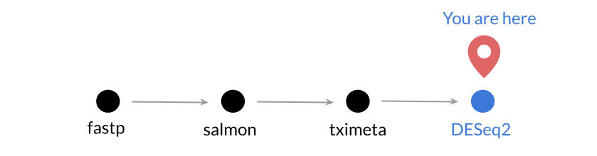

`DESeq2` also has an [excellent vignette](https://bioconductor.org/packages/release/bioc/vignettes/DESeq2/inst/doc/DESeq2.html) from Love, Anders, and Huber from which this is adapted (see also: [Love, Anders, and Huber. *Genome Biology*. 2014.](https://doi.org/10.1186/s13059-014-0550-8)).

## Libraries and functions

```r
# Load the DESeq2 library
library(DESeq2)
```

## Directories and files

```r
# Main data directory
data_dir <- file.path("data", "gastric-cancer")

# directory with the tximeta processed data
txi_dir <- file.path(data_dir, "txi")
txi_file <- file.path(txi_dir, "gastric-cancer_tximeta.rds")
```

We’ll create a directory to hold our plots.

```r
# Create a plots directory if it does not exist yet
plots_dir <- file.path("plots", "gastric-cancer")
fs::dir_create(plots_dir)
```

**Output**

```r
# We will save a PDF copy of the PCA plot to the plots directory
# and name the file "gastric-cancer_PC_scatter.pdf"
pca_plot_file <- file.path(plots_dir, "gastric-cancer_PC_scatter.pdf")
```

## DESeq2

### Creating a DESeq2 dataset from a tximeta object

First, let’s read in the data we processed with `tximeta`.

```r
# Read in the RDS file we created in the last notebook
gene_summarized <- readr::read_rds(txi_file)
```

### Set up DESeq2 object

We use the tissue of origin in the design formula because that will allow us to model this variable of interest.

```r
ddset <- DESeqDataSet(gene_summarized, design = ~tissue)
```

```
using counts and average transcript lengths from tximeta
```

### Variance stabilizing transformation

Raw count data is not usually suitable for the algorithms we use for dimensionality reduction, clustering, or heatmaps. To improve this, we will transform the count data to create an expression measure that is better suited for these analyses. The core transformation will map the expression to a log2 scale, while accounting for some of the expected variation among samples and genes.

Since different samples are usually sequenced to different depths, we want to transform our RNA-seq count data to make different samples more directly comparable. We also want to deal with the fact that genes with low counts are also likely to have higher variance (on the log2 scale), as that could bias our clustering. To handle both of these considerations, we can calculate a Variance Stabilizing Transformation of the count data, and work with that transformed data for our analysis.

See [this section of the `DESeq2` vignette](https://bioconductor.org/packages/release/bioc/vignettes/DESeq2/inst/doc/DESeq2.html#data-transformations-and-visualization) for more on this topic.

```r
vst_data <- vst(ddset)
```

```
using 'avgTxLength' from assays(dds), correcting for library size
```

### Principal component analysis

Principal component analysis (PCA) is a dimensionality reduction technique that allows us to identify the largest components of variation in a complex dataset. Our expression data can be thought of as mapping each sample in a multidimensional space defined by the expression level of each gene. The expression of many of those genes are correlated, so we can often get a better, simpler picture of the data by combining the information from those correlated genes.

PCA rotates and transforms this space so that each axis is now a combination of multiple correlated genes, ordered so the first axes capture the most variation from the data. These new axes are the “principal components.” If we look at the first few components, we can often get a nice overview of relationships among the samples in the data.

The `plotPCA()` function we will use from the `DESeq2` package calculates and plots the first two principal components (PC1 and PC2). Visualizing PC1 and PC2 can give us insight into how different variables (e.g., tissue source) affect our dataset and help us spot any technical effects (more on that below).

```
using ntop=500 top features by variance
```

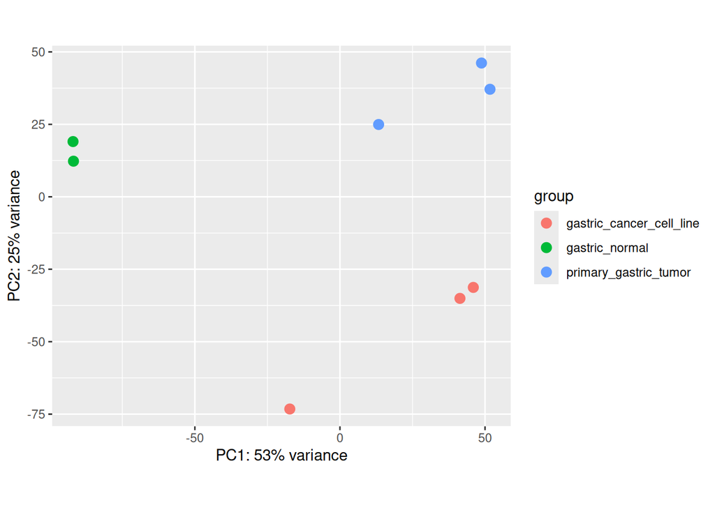

```r
# DESeq2 built in function is called plotPCA and we want to
# color points by tissue
plotPCA(vst_data, intgroup = "tissue")
```

Save the most recent plot to file with `ggsave` from `ggplot2`

```r
# Save plot as a PDF file
# Note that `last_plot()` is the default, but we are making it explicit here
ggplot2::ggsave(pca_plot_file, plot = ggplot2::last_plot())
```

## A note on technical effects

We don’t have batch information (i.e., when the samples were run) for this particular experiment, but let’s imagine that `SRR585574` and `SRR585576` were run separately from all other samples. We’ll add this as a new “toy” column in the sample data (`colData`).

```r
# Extract colData
sample_info <- colData(vst_data)

# Print out preview
sample_info
```

```
DataFrame with 8 rows and 3 columns
                names                   tissue                  title
          <character>                 <factor>            <character>
SRR585570   SRR585570 gastric_normal           Gastric normal (CGC-..
SRR585571   SRR585571 gastric_normal           Gastric normal (CGC-..
SRR585572   SRR585572 primary_gastric_tumor    Primary gastric tumo..
SRR585573   SRR585573 primary_gastric_tumor    Primary gastric tumo..
SRR585574   SRR585574 primary_gastric_tumor    Primary gastric tumo..
SRR585575   SRR585575 gastric_cancer_cell_line                 SNU484
SRR585576   SRR585576 gastric_cancer_cell_line                 SNU601
SRR585577   SRR585577 gastric_cancer_cell_line                 SNU668
```

Now we can add a new column with toy batch information and re-store the `colData()`.

```r
# Add batch information
sample_info$batch <- c("batch1", "batch1", "batch1", "batch1",
                       "batch2", "batch1", "batch2", "batch1")
```

If this batch information were real we would have included it with the sample metadata when we made the original `SummarizedExperiment` object with `tximeta`. We would then include it in the model stored in our DESeq2 object using the `design` argument (`design = ~ tissue + batch`) and we would re-run the `DESeqDataSet()` and `vst()` steps we did above. Here we will take a bit of a shortcut and add it directly to the `colData()` for our `vst()`-transformed data.

```r
# Add updated colData() with batch info to vst_data
colData(vst_data) <- sample_info
```

```r
# PCA plot - tissue *and* batch
# We want plotPCA to return the data so we can have more control about the plot
pca_data <- plotPCA(
  vst_data,
  intgroup = c("tissue", "batch"),
  returnData = TRUE
)
```

```
using ntop=500 top features by variance
```

```r
# Here we are setting up the percent variance that we are extracting from the `pca_data` object
percent_var <- round(100 * attr(pca_data, "percentVar"))
```

Let’s use ggplot to visualize the first two principal components.

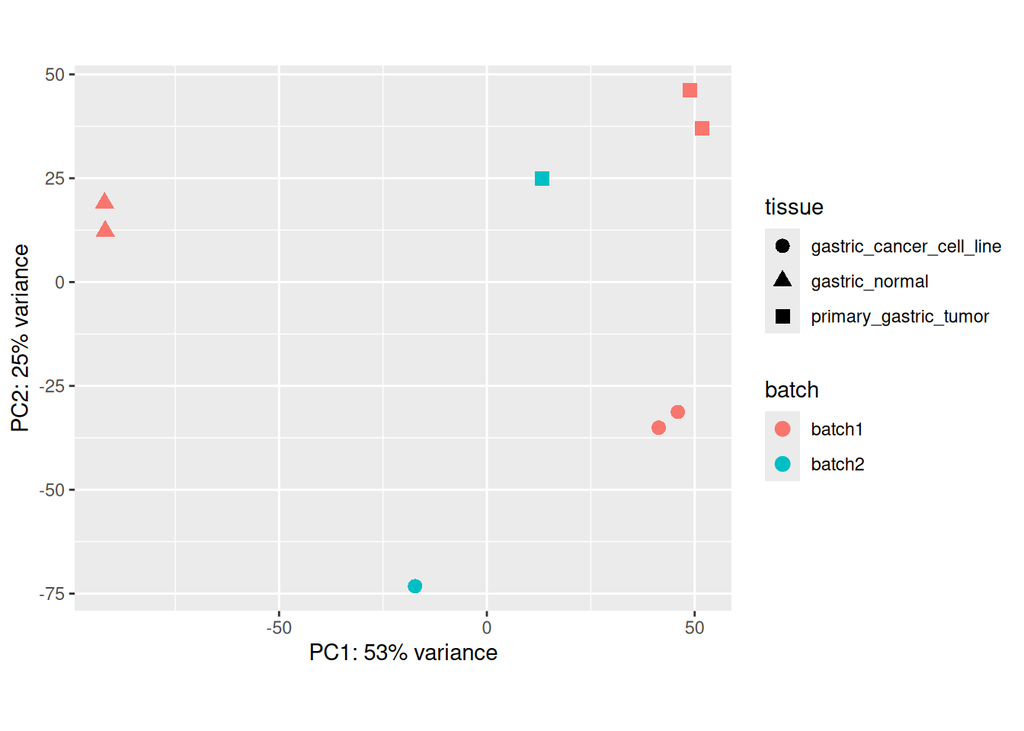

```r
# Color points by "batch" and use shape to indicate the tissue of origin
ggplot2::ggplot(pca_data,
  ggplot2::aes(
    x = PC1,
    y = PC2,
    color = batch,
    shape = tissue
  )
) +
  ggplot2::geom_point(size = 3) +
  ggplot2::xlab(paste0("PC1: ", percent_var[1], "% variance")) +
  ggplot2::ylab(paste0("PC2: ", percent_var[2], "% variance")) +
  ggplot2::coord_fixed()
```